# Visualization and Transformation

Group 5

3/18/2023

# Retrieve Data

- The Dataset already has the train and test seperated so no need to do it manually

```r
Dir <- 'Datasets/Tweets_with_Sarcasm_and_Irony'
train <- read_csv(paste0(Dir,"/train.csv"))
test <- read_csv(paste0(Dir,"/test.csv"))
#test <- test %>% filter(!is.na(class))
```

```r
train$tweets <- map(train$tweets, .f = function(x){
  str_squish(x)
}) %>% unlist()
```

# Some Exploration

- Shows how many observation exists for each dataset

```r
classes <- train$class %>% unique()
num_obs_train <- nrow(train)
num_obs_test <- nrow(test)
```

Classes: figurative, irony, regular, sarcasm  
Number of observations in Train: 81408  
Number of observations in Test: 8128

- Demonstrates the number of different classes exists

```r
t <- train %>% group_by(class) %>% count()
kable(t)
```

| class | n |
| --- | --- |
| figurative | 21238 |
| irony | 20894 |
| regular | 18595 |
| sarcasm | 20681 |

- View the missing data, we consider empty strings as missing data aswell

```r
train %>% filter(tweets == "" | tweets == " " | is.na(tweets))
```

```
## # A tibble: 0 × 2
## # … with 2 variables: tweets <chr>, class <chr>
```

*Visulaize tweet length range

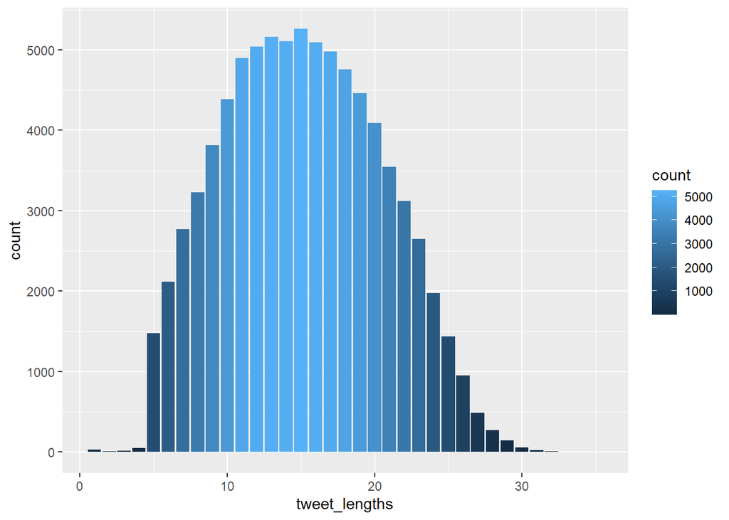

```r
tweet_lengths <- train$tweets %>% map(
              .f = function(x){
  str_count(x, pattern = " ") + 1
}) %>% unlist()

ids <- 1:nrow(train)
train_temp <- train %>% mutate(tweet_length = tweet_lengths,
                               id = ids)

train_temp %>% ggplot(aes(x = tweet_lengths)) +
  geom_bar(aes(fill = after_stat(count)))
```

*Tweet length range visualized with box plot

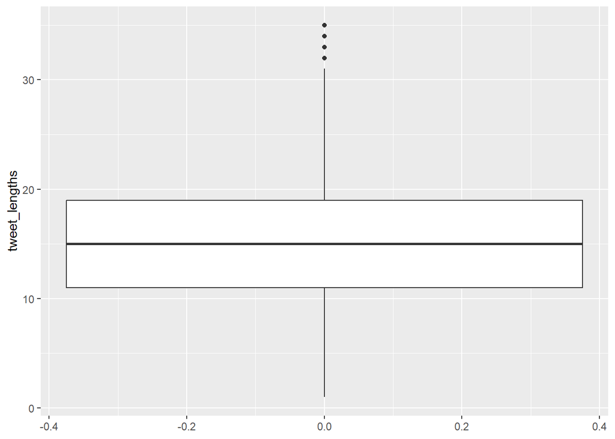

```r
train_temp %>% ggplot(aes(y = tweet_lengths)) +
  geom_boxplot()
```

*Tweet length range visualized with boxplot for each class

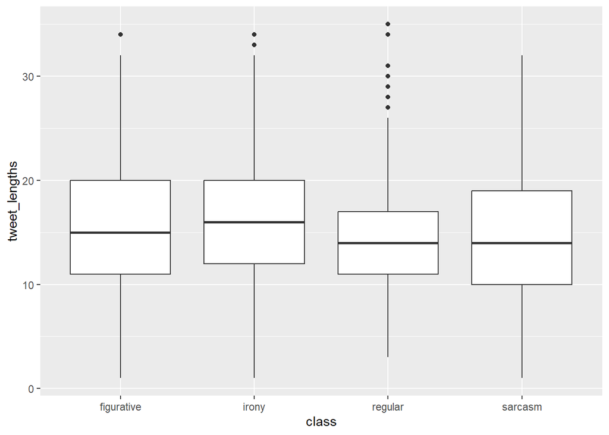

```r
train_temp %>% ggplot(aes(x = class, y = tweet_lengths)) +
  geom_boxplot()
```

Max tweet length: 35  
Min tweet length: 1  
Mean tweet length: 15.1533142

```r
t <- train_temp %>% filter(tweet_lengths == max(tweet_lengths))
kable(t)
```

| tweets | class | tweet_length | id |
| --- | --- | --- | --- |
| Thanks to #GOPDebate candidates, I learned that George W. Bush KEPT US SAFE ! * . . . . . . . . . . . . . *Except for 9/11, Iraq War, & ISIS | regular | 35 | 55929 |

```r
t <- train_temp %>% filter(tweet_lengths == min(tweet_lengths))
kable(t)
```

| tweets | class | tweet_length | id |
| --- | --- | --- | --- |
| #Science | figurative | 1 | 4232 |
| #irony | figurative | 1 | 6398 |
| http://t.co/1jrya1kJdQ | figurative | 1 | 8618 |
| #ironic | figurative | 1 | 8835 |
| #Irony | figurative | 1 | 11012 |
| #Irony | figurative | 1 | 12618 |
| #Sarcasm | figurative | 1 | 12963 |
| #sarcasm | figurative | 1 | 17739 |
| #irony | figurative | 1 | 17821 |
| #sarcasm | figurative | 1 | 21105 |
| http://t.co/3GH9aVFCLv | irony | 1 | 22488 |
| #Science | irony | 1 | 26092 |
| #irony | irony | 1 | 28513 |
| #Ironic | irony | 1 | 30011 |
| http://t.co/1jrya1kJdQ | irony | 1 | 31029 |
| #ironic | irony | 1 | 31125 |
| #ironic | irony | 1 | 31251 |
| #Irony | irony | 1 | 33844 |
| #StupidCollegePeople | irony | 1 | 34850 |
| #Irony | irony | 1 | 35872 |
| #irony | irony | 1 | 36718 |
| @sonaliranade | irony | 1 | 38441 |
| #sarcasm | sarcasm | 1 | 63044 |
| #Sarcasm | sarcasm | 1 | 64337 |
| #Sarcasm | sarcasm | 1 | 68456 |
| http://t.co/kBrSaRHC98 | sarcasm | 1 | 76057 |
| #sarcasm | sarcasm | 1 | 78045 |
| #sarcasm | sarcasm | 1 | 78434 |

# Functions

- Some functions for transformation, most notable, get_hashtags_df mutates hashtags from tweets into a new column.
- Takes in a list of strings

```r
#------------------------------------------------------------------------------
#Function just so i don't loose my mind waiting for a function to finish
#P: Makes sure function does not print the same percentage: initialize p = 0
#outside the loop
#Length: How long the loop is
#i: the iterator
print_percent <- function(i, length, p) {
  percent <- floor((i/length * 100))
  if(percent %% 10 == 0 && p != percent){
      print(paste0(percent,"% Complete"))
      p = percent
    }
    return(p)
}
#------------------------------------------------------------------------------
#Seperates hashtags from text
#Takes in a column of text and returns a list of hash tags
get_hashtags_df <- function(text) {
  tweets <- text
  tweets_separated <- tweets %>% str_split(pattern = " ")
  y <- list()
  p = 0
  for (i in 1:length(tweets_separated)) {
    hashtags <- list()
    for(k in 1:length(tweets_separated[[i]])){
      if(grepl(tweets_separated[[i]][k], pattern = "#.*")){
        hashtags <- append(hashtags,tweets_separated[[i]][k])
      }
    }
    #print(hashtags)
    y <- append(y,list(hashtags))
    #assign("y", y, envir = .GlobalEnv)
    #print(y)


    p = print_percent(i,length = length(tweets_separated), p = p)
    #print()#," Percent complete")

   #print(tweets_separated[[i]])
  }
  y
}
```

# Read in Data

```r
Dir <- 'Datasets/Tweets_with_Sarcasm_and_Irony'
train <- read_csv(paste0(Dir,"/train.csv"))
test <- read_csv(paste0(Dir,"/test.csv"))
#test <- test %>% filter(!is.na(class))
```

# Separate Hashtags from text into a new column

```r
Dir <- 'Datasets/Tweets_with_Sarcasm_and_Irony'
train <- read_csv(paste0(Dir,"/train.csv"))
#tweets <- train$tweets
y <- get_hashtags_df(train$tweets)
train$tweets <- train$tweets %>% sub(pattern = "#.* | #.*$", replacement = "")
train <- train %>% mutate(hashtags = y)
#Note to load from disk use load("Datasets/train_w_hashtags.RData") in the markdown file
save(train, file="Datasets/train_w_hashtags.RData")



test <- read_csv(paste0(Dir,"/test.csv"))
y <- get_hashtags_df(train$tweets)
train$tweets <- train$tweets %>% sub(pattern = "#.* | #.*$", replacement = "")
train <- train %>% mutate(hashtags = y)
#Note to load from disk use load("Datasets/test_w_hashtags.RData") in the markdown file
save(test, file="Datasets/test_w_hashtags.RData")
```

- Preprocessing function for cleaning tweet column

```r
preprocessing <- function(data) {
    require('tm')
    require('stopwords')

    data$tweets <- data$tweets %>% sub(pattern = "@.* | @.*$", replacement = "")
    data$tweets <- tolower(data$tweets)
    data$tweets <- removePunctuation(data$tweets)
    data$tweets <- removeWords(data$tweets, words = stopwords('en'))
    data <- data  %>% filter(tweets != "")
    data
}


load('Datasets/Tweets_with_Sarcasm_and_Irony/train_w_hashtags.Rdata')
train <- preprocessing(train)
train[1:20,] %>% kable()
```

| tweets | class | hashtags |
| --- | --- | --- |
| aware dirty step get money | figurative | #staylight , #staywhite , #sarcastic , #moralneeded |
| httptcortyymudvus | figurative | #sarcasm , #people , #diy , #artattack |
| medsingle | figurative | #DailyMail , #shocker , #sarcastic , #dailyfail , #inHuntspocket , #theyhatethenhs |
| games | figurative | #sarcasm |
| text | figurative | #sarcastic |
| tune nigezie treated rachel plattens fight song move mtv get reminisce amp olamides local rapper | figurative | #Irony , #TimesChange |
| iz thiz friggin dc love fest | figurative | #Sarcasm , #MovieFights |
| man wish sexually harass intoxicated minor go jail | figurative | #sarcasm |
| either | figurative | #sarcasm |
| aamir calls | figurative | #BajrangiBhaijaan, #sarcasm |
| httpstcowa4p63limd | figurative | #work , #yay , #sarcasm , #fuck , #goodnight |
| best | figurative | #Sarcasm |
| foot | figurative | #sarcasm |
| dont think tv show | figurative | #Epic , #MasterShowman!, #sarcastic |
| go another day paradise | figurative | #sarcasm |
| jobs great love operate rides kids sometimes weathers right get shower | figurative | #rain , #sarcasm |
| quotestagsapp | figurative | #funnyquotes , #insult , #sarcasticquotes, #sarcasm , #quote , #quotestags |
| loving | figurative | #TheOpen, #Sarcasm |
| strop just pitch around double game line couldnt tell paying attention hat | figurative | #sarcasm, #Cubs |
| keep close see theyre 🕠🕠 | figurative | #sarcastic, #sassy |

```r
train$hashtags %>% head()
```

```
## [[1]]
## [[1]][[1]]
## [1] "#staylight"
##
## [[1]][[2]]
## [1] "#staywhite"
##
## [[1]][[3]]
## [1] "#sarcastic"
##
## [[1]][[4]]
## [1] "#moralneeded"
##
##
## [[2]]
## [[2]][[1]]
## [1] "#sarcasm"
##
## [[2]][[2]]
## [1] "#people"
##
## [[2]][[3]]
## [1] "#diy"
##
## [[2]][[4]]
## [1] "#artattack"
##
##
## [[3]]
## [[3]][[1]]
## [1] "#DailyMail"
##
## [[3]][[2]]
## [1] "#shocker"
##
## [[3]][[3]]
## [1] "#sarcastic"
##
## [[3]][[4]]
## [1] "#dailyfail"
```

[output cut: 9 more lines]

```
## [[4]][[1]]
## [1] "#sarcasm"
##
##
## [[5]]
## [[5]][[1]]
## [1] "#sarcastic"
##
##
## [[6]]
## [[6]][[1]]
## [1] "#Irony"
##
## [[6]][[2]]
## [1] "#TimesChange"
```

```r
train <- read.csv('Datasets/Tweets_with_Sarcasm_and_Irony/train.csv')
test <- read.csv('Datasets/Tweets_with_Sarcasm_and_Irony/test.csv')
```

#Filter tweets with their classes

```r
figurativeSet <- filter(train, class=="figurative")

ironySet <- filter(train, class == "irony")

sarcasmSet <- filter(train, class =="sarcasm")

regularSet <- filter(train, class =="regular")


not_regularSet <- filter(train, class != "regular")
```

#Collect the words and their frequencies from the set

```r
freq_figurative <- as.data.frame(sort(table(unlist(strsplit(figurativeSet$tweets," "))), decreasing = TRUE), stringsAsFactors = FALSE)
summary(freq_figurative)
```

```
##      Var1                Freq
##  Length:73284       Min.   :   1.000
##  Class :character   1st Qu.:   1.000
##  Mode  :character   Median :   1.000
##                     Mean   :   4.469
##                     3rd Qu.:   1.000
##                     Max.   :8721.000
```

```r
freq_irony <- as.data.frame(sort(table(unlist(strsplit(ironySet$tweets," "))), decreasing = TRUE), stringsAsFactors = FALSE)

freq_sarcasm <- as.data.frame(sort(table(unlist(strsplit(sarcasmSet$tweets," "))), decreasing = TRUE), stringsAsFactors = FALSE)

freq_regular <- as.data.frame(sort(table(unlist(strsplit(regularSet$tweets," "))), decreasing = TRUE), stringsAsFactors = FALSE)

freq_not_regular <- as.data.frame(sort(table(unlist(strsplit(not_regularSet$tweets," "))), decreasing = TRUE), stringsAsFactors = FALSE)
```

#Key objects: frequency sets

```r
dfSubsetFigurative <- subset(freq_figurative, Freq > 100, stringsAsFactors = FALSE)

dfSubsetIrony <- subset(freq_irony, Freq > 100, stringsAsFactors = FALSE)

dfSubsetSarcasm <- subset(freq_sarcasm, Freq > 100, stringsAsFactors = FALSE)

dfSubsetRegular <- subset(freq_regular, Freq > 100, stringsAsFactors = FALSE)
```

#Now to make the wordcloud #Code:

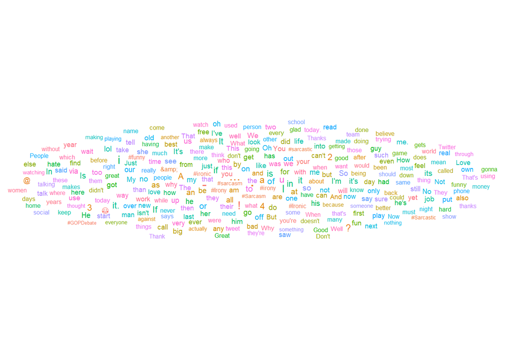

```r
#figurative
set.seed(42)
ggplot(dfSubsetFigurative, aes(label = Var1, size = length(Var1), color = Var1)) +
  geom_text_wordcloud_area(eccentricity = .35) +
  scale_size_area(max_size = 24) +
  theme_minimal()
```

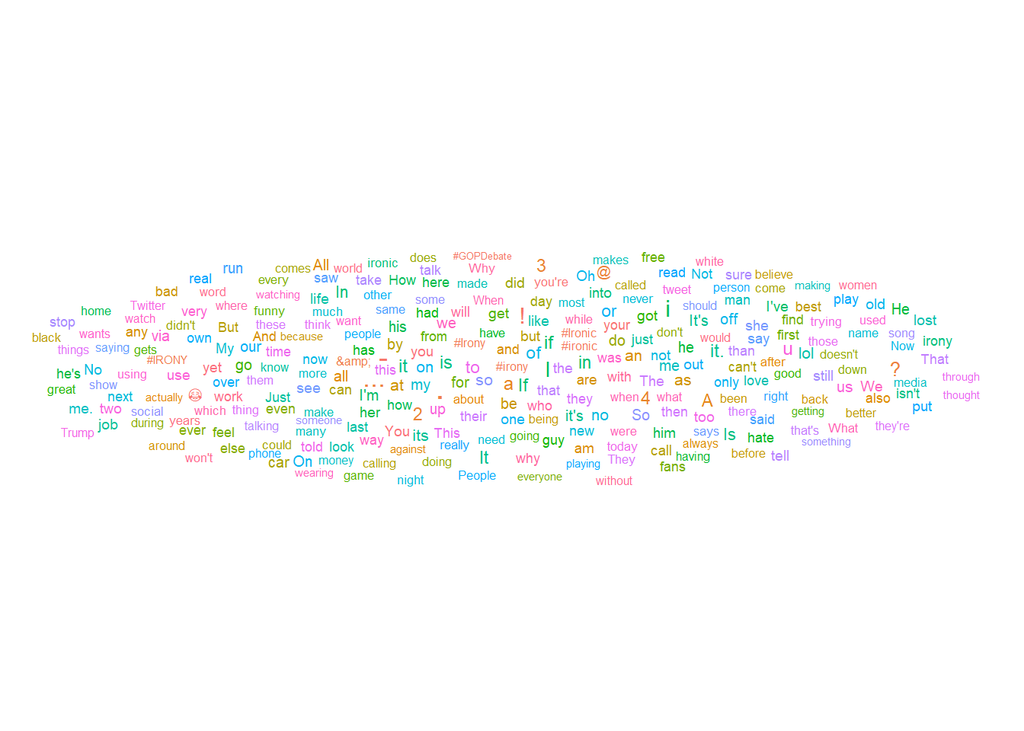

```r
#irony
set.seed(42)
ggplot(dfSubsetIrony, aes(label = Var1, size = length(Var1), color = Var1)) +
  geom_text_wordcloud_area(eccentricity = .35) +
  scale_size_area(max_size = 24) +
  theme_minimal()
```

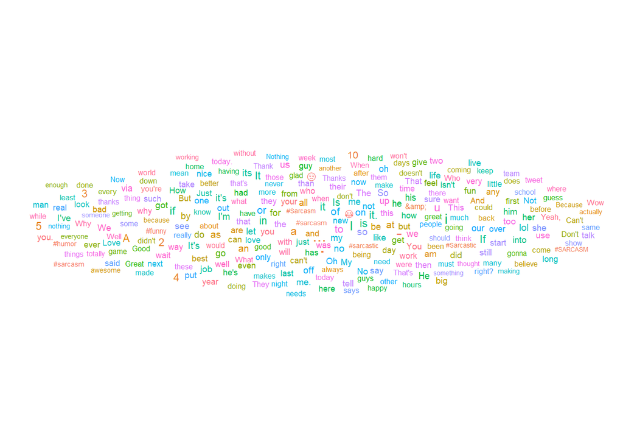

```r
#sarcasm
set.seed(42)
ggplot(dfSubsetSarcasm, aes(label = Var1, size = length(Var1), color = Var1)) +
  geom_text_wordcloud_area(eccentricity = .35) +
  scale_size_area(max_size = 24) +
  theme_minimal()
```

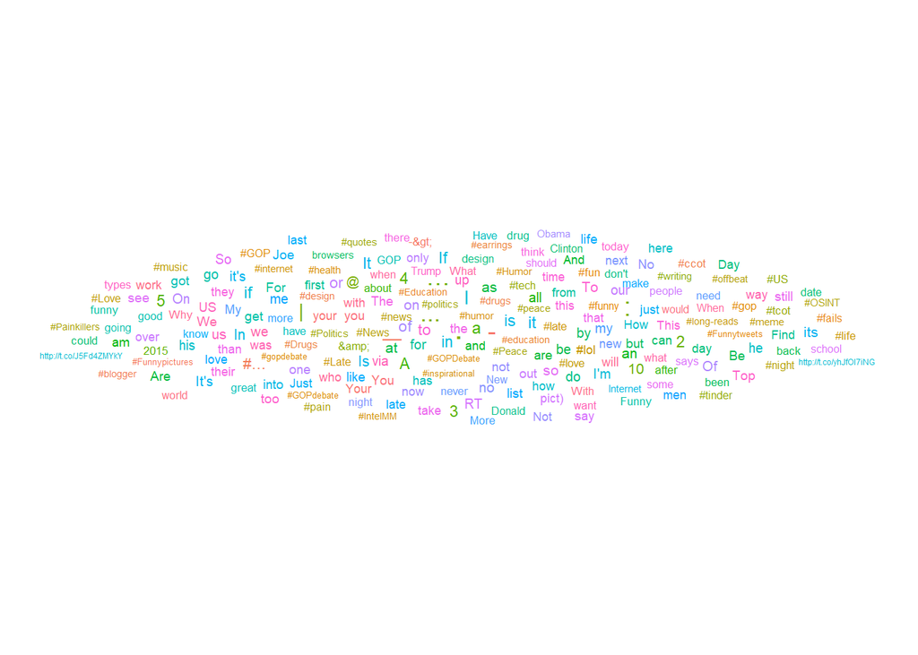

[figure not shown]

[figure not shown]

[figure not shown]

[figure not shown]

```r
#regular
set.seed(42)
ggplot(dfSubsetRegular, aes(label = Var1, size = length(Var1), color = Var1)) +
  geom_text_wordcloud_area(eccentricity = .35) +
  scale_size_area(max_size = 24) +
  theme_minimal()
```

# Figurative Class Outiers

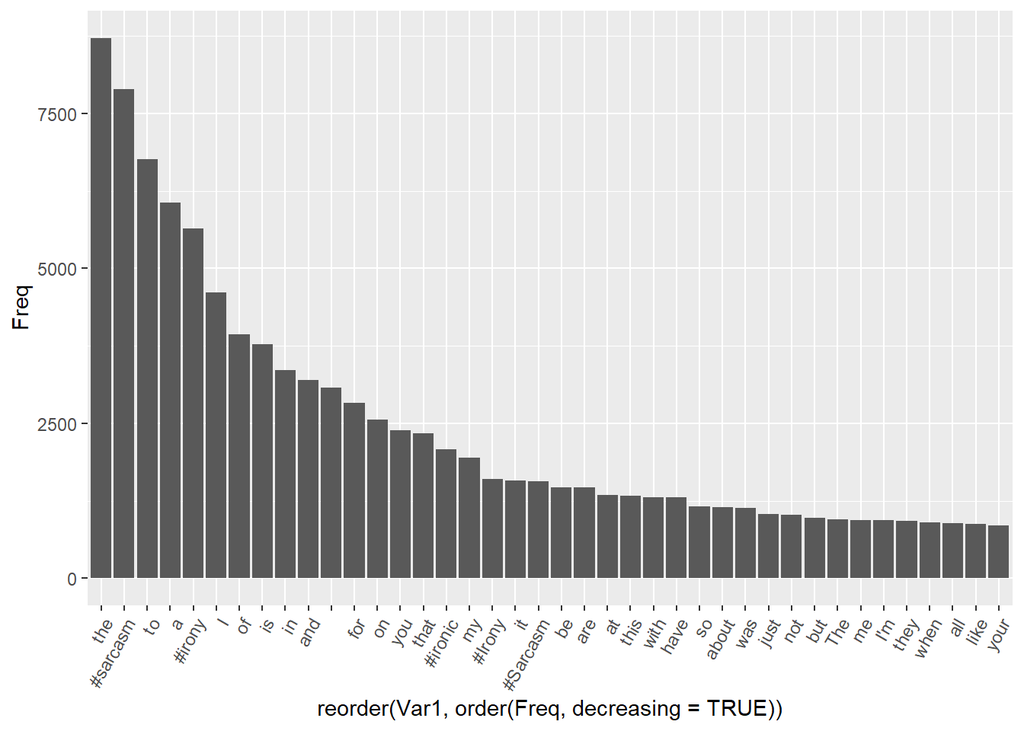

```r
 outlierSubsetFigurative <- subset(freq_figurative, Freq > 851, stringsAsFactors = FALSE)
  outlierSubsetFigurative %>%
    ggplot(aes(x = reorder(Var1, order(Freq, decreasing = TRUE)), y = Freq)) +
        geom_bar(stat = 'identity')  +
          theme(axis.text.x = element_text(angle = 60, hjust = 1))
```

# Irony Class Outiers

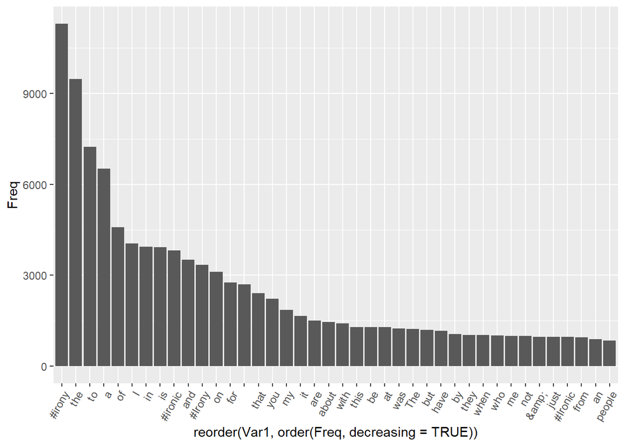

```r
  outlierSubsetIrony <- subset(freq_irony, Freq > 851, stringsAsFactors = FALSE)
  outlierSubsetIrony %>%
    ggplot(aes(x = reorder(Var1, order(Freq, decreasing = TRUE)), y = Freq)) +
        geom_bar(stat = 'identity')  +
          theme(axis.text.x = element_text(angle = 60, hjust = 1))
```

# Sarcasm Class Outiers

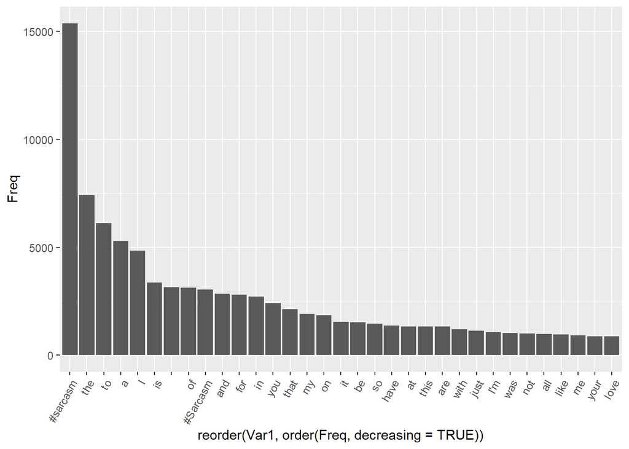

```r
  outlierSubsetSarcasm <- subset(freq_sarcasm, Freq > 851, stringsAsFactors = FALSE)
  outlierSubsetSarcasm %>%
    ggplot(aes(x = reorder(Var1, order(Freq, decreasing = TRUE)), y = Freq)) +
        geom_bar(stat = 'identity')  +
          theme(axis.text.x = element_text(angle = 60, hjust = 1))
```

# Regular Class Outiers

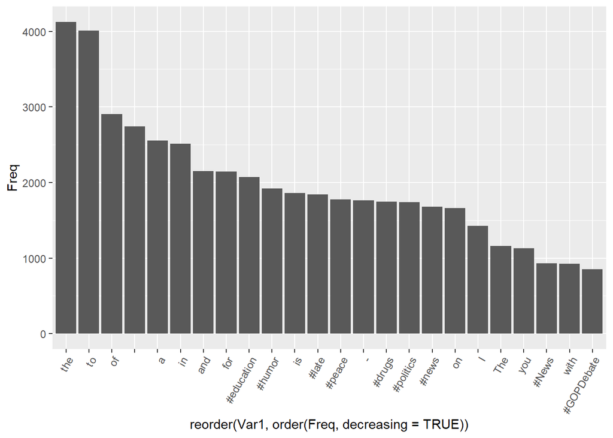

```r
  outlierSubsetRegular <- subset(freq_regular, Freq > 851, stringsAsFactors = FALSE)
  outlierSubsetRegular %>%
    ggplot(aes(x = reorder(Var1, order(Freq, decreasing = TRUE)), y = Freq)) +
        geom_bar(stat = 'identity')  +
          theme(axis.text.x = element_text(angle = 60, hjust = 1))
```

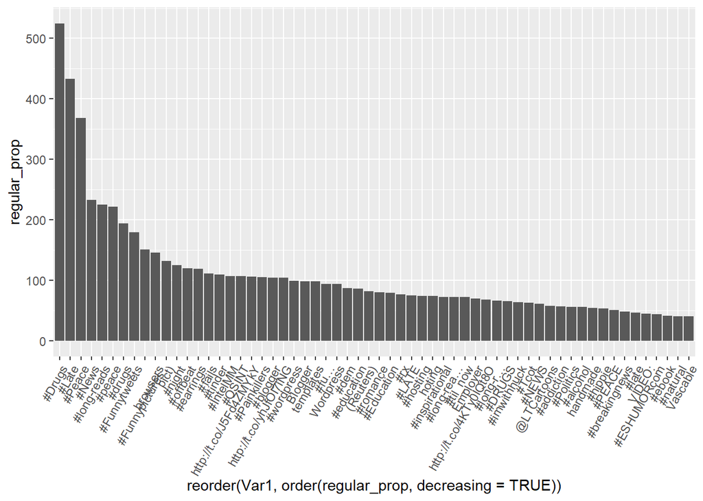

```r
frequencys <- full_join(freq_figurative,freq_irony, by = "Var1") %>%
  full_join(freq_regular, by = "Var1") %>%
  full_join(freq_sarcasm, by = "Var1") %>%
  rename(figurative = Freq.x,
         irony = Freq.y,
         regular = Freq.x.x,
         sarcasm = Freq.y.y)


frequencys_2_class <-  full_join(freq_regular,freq_not_regular, by = "Var1") %>%
   rename(regular = Freq.x,
         not_regular = Freq.y)


frequencys_2_class[frequencys_2_class == 0] <- 1
frequencys_2_class[is.na(frequencys_2_class)] <- 1


frequencys[frequencys == 0] <- 1
frequencys[is.na(frequencys)] <- 1

frequencys <- frequencys %>%
  mutate(figurative_prop = figurative/(irony * regular * sarcasm)) %>%
  mutate(irony_prop = irony/(figurative * regular * sarcasm)) %>%
  mutate(sarcasm_prop = sarcasm/(figurative * regular * irony)) %>%
  mutate(regular_prop = regular/(figurative * sarcasm * irony))


frequencys_2_class <- frequencys_2_class %>%
  mutate(prop = regular/not_regular) %>%
  mutate(inv_prop = not_regular/regular)



max = 60
#graph_freq <- function(df, max_entries = 60) {
  frequencys %>%
  arrange(desc(regular_prop)) %>%
  slice(1:max) %>%
  ggplot(aes(y = regular_prop, x = reorder(Var1, order(regular_prop, decreasing = TRUE)))) +
  geom_bar(stat='identity') +
  theme(axis.text.x = element_text(angle = 60, hjust = 1))
```

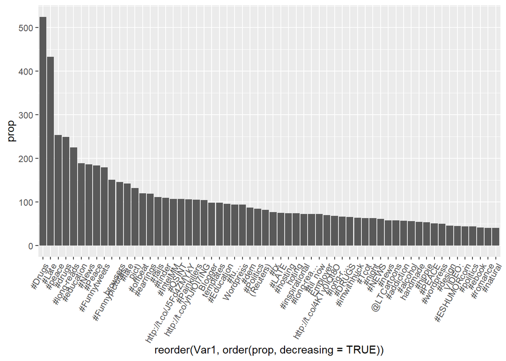

```r
#}

  frequencys_2_class %>%
  arrange(desc(prop)) %>%
  slice(1:max) %>%
  ggplot(aes(y = prop, x = reorder(Var1, order(prop, decreasing = TRUE)))) +
  geom_bar(stat='identity') +
  theme(axis.text.x = element_text(angle = 60, hjust = 1))
```

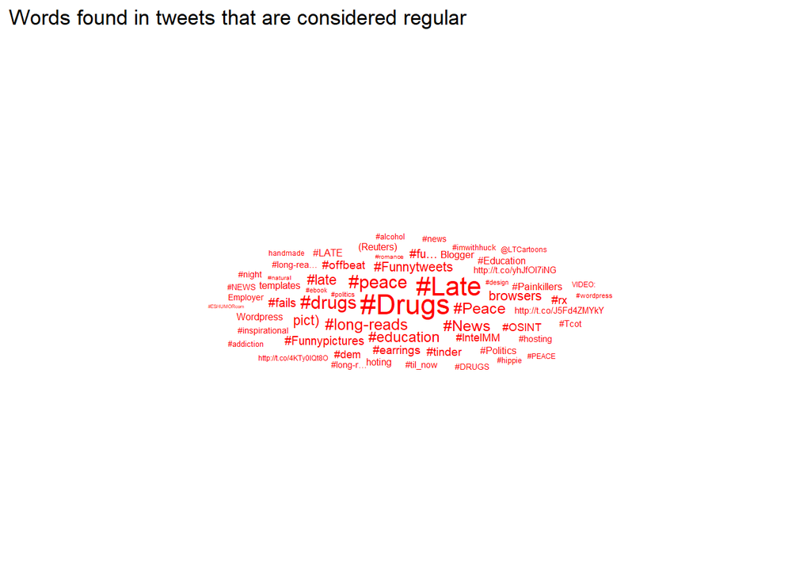

```r
max = 60
frequencys_tmp_prop <- frequencys_2_class %>%
  arrange(desc(prop)) %>%
  slice(1:max)

frequencys_tmp_inv_prop <- frequencys_2_class %>%
  arrange(desc(inv_prop)) %>%
  slice(1:max)


ggplot(frequencys_tmp_prop, aes(label = Var1, size = prop)) +
  geom_text_wordcloud_area(eccentricity = .54, color = 'red') +
  #scale_size_area(max_size = 30) +
  theme_minimal() +
  ggtitle ('Words found in tweets that are considered regular')
```

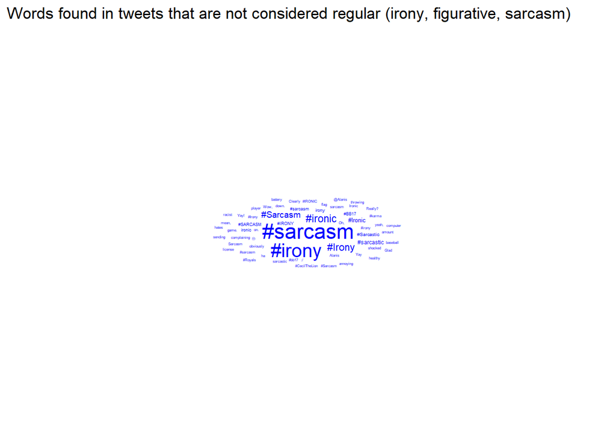

```r
ggplot(frequencys_tmp_inv_prop, aes(label = Var1, size = inv_prop)) +
  geom_text_wordcloud_area(eccentricity = .54, color = 'blue') +
  #scale_size_area(max_size = 30) +
  theme_minimal() +
  ggtitle ('Words found in tweets that are not considered regular (irony, figurative, sarcasm)')
```